# Instrumental Variables Estimation

Paul Schrimpf

2025-11-24

## Reading

- Required: **Song (2021) chapter 12**

$$\def\Er{{\mathrm{E}}}
\def\En{{\mathbb{E}_n}}
\def\cov{{\mathrm{Cov}}}
\def\var{{\mathrm{Var}}}
\def\R{{\mathbb{R}}}
\def\indep{{\perp\!\!\!\perp}}
\newcommand\norm[1]{\left\lVert#1\right\rVert}
\def\rank{{\mathrm{rank}}}
\newcommand{\inpr}{ \overset{p^*_{\scriptscriptstyle n}}{\longrightarrow}}
\def\inprob{{\,{\buildrel p \over \rightarrow}\,}}
\def\indist{\,{\buildrel d \over \rightarrow}\,}
\DeclareMathOperator*{\plim}{plim}$$

# Instrumental Variables

## Model

$$Y_i = \underbrace{X_i}_{\in \R^k}' \beta_0 + u_i$$

- $\Er[u_i] = 0$, but $\Er[X_i u_i] \neq 0$
- Instrument $Z_i \in \R^d$ s.t.
  1. Relevant $rank(\Er[Z_i X_i']) = k$
  2. Exogenous $\Er[Z_i u_i] = 0$

## Identification

- Exogeneity implies
  $$\Er[Z_i Y_i] = \Er[Z_i X_i']\beta_0$$
- If $d=k$ (exactly identified), then relevance implies $\Er[Z_i X_i']$ invertible, so
  $$\beta_0 = \Er[Z_i X_i']^{-1} \Er[Z_i Y_i]$$
- For $d>k$, relevance implies $\Er[Z_iX_i']'\Er[Z_iX_i']$ invertible, so
  $$\beta_0 = (\Er[Z_i X_i]' \Er[Z_i X_i'])^{-1} \Er[Z_i X_i']' \Er[Z_i Y_i]$$

# Estimation

## Method of Moments Estimation

- We assume $\Er[Z_i u_i] = 0$, so
  $$\Er[Z_i(Y_i - X_i'\beta_0)] = 0$$
- Estimate by replacing $\Er$ with $\frac{1}{n}\sum_{i=1}^n$

## Method of Moments Estimation

$$\hat{\beta}^{IV}
= \mathrm{arg}\min_\beta \left( \frac{1}{n} \sum_{i=1}^n Z_i(Y_i - X_i'\beta\right)' W \left( \frac{1}{n} \sum_{i=1}^n Z_i(Y_i - X_i'\beta\right)$$

- $\hat{\beta}^{IV}_W = (X'Z W Z'W)^{-1}(X'Z W Z'y)$

# Asymptotic Properties

## Consistency

$$\begin{align*}
\hat{\beta}^{IV}_W - \beta_0 = & (X'Z W Z'W)^{-1}(X'Z W Z'u) \\
= & \left[ \left(\frac{1}{n}\sum_{i=1}^n X_i Z_i'\right) W \left(\frac{1}{n}\sum_{i=1}^n Z_i X_i'\right) \right]^{-1}
\left(\frac{1}{n}\sum_{i=1}^n X_i Z_i'\right) W \left(\frac{1}{n}\sum_{i=1}^n Z_i u_i\right)
\end{align*}$$

- Consistent if LLN applies to $\frac{1}{n}\sum_{i=1}^n Z_i X_i'$ and $\frac{1}{n}\sum_{i=1}^n Z_i u_i$
  - E.g. if i.i.d. with $\Er[\norm{X_i}^4]$ and $\Er[\norm{Z_i}^4]$ finite and $\Er[u_i^2|Z_i=z] = \sigma^2$ <sup>1</sup>
[^1]: these are stronger than needed, for LLN, but needed for CLT

## Asymptotic Normality

$$\begin{align*}
\hat{\beta}^{IV}_W - \beta_0 = & (X'Z W Z'W)^{-1}(X'Z W Z'u) \\
= & \left[ \left(\frac{1}{n}\sum_{i=1}^n X_i Z_i'\right) W \left(\frac{1}{n}\sum_{i=1}^n Z_i X_i'\right) \right]^{-1}
\left(\frac{1}{n}\sum_{i=1}^n X_i Z_i'\right) W \left(\frac{1}{n}\sum_{i=1}^n Z_i u_i\right)
\end{align*}$$

- $\sqrt{n}(\hat{\beta}^{IV} - \beta_0) \indist N(0, V)$ if LLN applies to $\frac{1}{n}\sum_{i=1}^n Z_i X_i'$ and CLT to $\frac{1}{\sqrt{n}}\sum_{i=1}^n Z_i u_i$
  - E.g. if i.i.d. with $\Er[\norm{X_i}^4]$ and $\Er[\norm{Z_i}^4]$ finite and $\Er[u_i^2|Z_i=z] = \sigma^2$
  - then $\frac{1}{\sqrt{n}} \sum Z_i u_i \indist N(0, \sigma^2 \Er[Z_iZ_i'])$
  - $V = \sigma^2 (\Er[Z_iX_i']' W \Er[Z_iX_i'])^{-1} (\Er[Z_iX_i']' W \Er[Z_i Z_i'] W \Er[Z_i X_i']) (\Er[Z_iX_i']' W \Er[Z_iX_i'])^{-1}$

## Optimal $W$

**Theorem 2.1**

$W^* = \Er[Z_iZ_i']^{-1}$ minimizes the asymptotic variance of $\hat{\beta}^{IV}_W$

- Estimate $\hat{W}^* = \left(\frac{1}{n} Z'Z\right)^{-1}$
  $$\hat{\beta}^{IV} = (X'Z (Z'Z)^{-1} Z' X)^{-1} (X'Z(Z'Z)^{-1}Z'y)$$

## Two Stage Least Squares

$$\begin{align*}
\hat{\beta}^{IV} & = (X'Z (Z'Z)^{-1} Z' X)^{-1} (X'Z(Z'Z)^{-1}Z'y) \\
& = (X'P_Z X)^{-1} (X' P_Z y) \\
& = ((P_Z X)'(P_Z X))^{-1} ((P_Z X)'y)
\end{align*}$$

1. Regress $X$ on $Z$, let $\hat{X} = P_Z X$
2. Regress $y$ on $\hat{X}$

## Testing Overidentifying Restrictions

**Theorem 2.3**

Let $\hat{C} = \left(\frac{1}{n} \sum_{i=1}^n Z_iZ_i' \hat{u}_i^2\right)^{-1}$. Assume:

1. $\Er[ \norm{X_i}^4] + \Er[\norm{Z_i}^4] < \infty$
2. $\Er[u|Z] = \sigma^2$
3. $\Er[Z_i Z_i']$ is positive definite

Then,
$$J \indist \chi^2_{d-k}$$

## Over-identifying Test

- Only has power when instruments have different covariances with $u$

```julia
using Distributions, LinearAlgebra
import PlotlyLight
function sim(n; d=3, EZu = zeros(d), Exu = 0.5, beta = 1, gamma = ones(d))
  zu = randn(n,d)
  Z = randn(n,d) + mapslices(x->x.*EZu, zu, dims=2)
  xu = randn(n)
  X = Z*gamma + xu*Exu
  u = vec(sum(zu,dims=2) + xu + randn(n))
  y = X*beta + u
  return(y,X,Z)
end

biv(y,X,Z) = (X'*Z*inv(Z'*Z)*Z'*X) \ (X'*Z*inv(Z'*Z)*Z'*y)

function J(y,X,Z)
  n = length(y)
  bhat = biv(y,X,Z)
  uhat = y - X*bhat
  C = inv(1/n*sum(z*z'*u^2 for (z,u) in zip(eachrow(Z),uhat)))
  Zu = Z'*uhat/n
  J = n*Zu'*C*Zu
end

S = 1_000
n = 100
j0s = [J(sim(n)...) for _ in 1:S]
j1s = [J(sim(n,EZu=[0.,0., 3.])...) for _ in 1:S]
j2s = [J(sim(n,EZu=[1.,1., 1.])...) for _ in 1:S]

plt = PlotlyLight.Plot()
plt(x=j0s, type="histogram", name="E[Zu] = 0")
plt(x=j1s, type="histogram", name="E[Zu] = [0,0,3]")
fig=plt(x=j2s, type="histogram", name="E[Zu] = [1,1,1]")

fig
```

# Weak Instruments

## Simulated Distribution of $\hat{\beta}^{IV}$

- First stage $X = Z\gamma + e$, simulation with $\Er[Z_i Z_i] = I$ and $e \sim N(0,0.25)$, so first stage $t \approx \sqrt{n}\gamma/0.5$
- Distribution of $\hat{\beta}^{IV}$ with $\gamma = 1$, $\gamma=0.2$, and $\gamma=0.1$

## Simulated Distribution of $\hat{\beta}^{IV}$

```julia
function tiv(y,X,Z; b0 = ones(size(X,2)))
  b = biv(y,X,Z)
  u = y - X*b
  V = var(u)*inv(X'*Z*inv(Z'*Z)*Z'*X)
  (b - b0)./sqrt.(diag(V))
end
n = 100
S = 10_000
plt = PlotlyLight.Plot()
for g in [1, 0.2, 0.1]
  b = [tiv(sim(n,d=1,EZu=0,gamma=g)...)[1] for _ in 1:S]
  # crop outliers so figure looks okay
  b .= max.(b, -4)
  b .= min.(b, 4)
  plt(x=b, type="histogram",name="γ=$g")
end
fig=plt(x=randn(S), type="histogram", name="Normal")

fig
```

## Weak Instruments

- Lessons from simulation:
  - When $\Er[Z_i X_i']$ is small, usual asymptotic distribution is a poor approximation for the finite sample distribution of $\hat{\beta}^{IV}$
  - The approximation can be poor even when $H_0: \gamma = 0$ in $X = Z\gamma + e$ would be rejected
- Can we find a better approximation to the finite sample distribution when $\Er[Z_i X_i']$ is small?

## Irrelevant Instrument Asymptotics

- Suppose $\Er[Z_i X_i'] = 0$
- CLT
  $$\frac{1}{\sqrt{n}} \begin{pmatrix}
  vec(Z'X) \\
  Z'u
  \end{pmatrix} \indist \begin{pmatrix} \zeta_1 \\ \zeta_2 \end{pmatrix} \sim N(0, \Sigma)$$
- Then
  $$\begin{align*}
  \hat{\beta}^{IV} - \beta_0 = & \left((Z'X)'(Z'Z)^{-1}(Z'X)\right)^{-1} (Z'X)'(Z'Z)^{-1}(Z'u) \\
  \indist & \left(H' \Er[Z_i Z_i]^{-1} H\right)^{-1} \left(H \Er[Z_i Z_i']^{-1} \zeta_2\right)
  \end{align*}$$
  where $vec(H) = \zeta_1$

## Weak Instrument Asymptotics

- Let $\Er[Z_i X_i'] = \frac{1}{\sqrt{n}} \Gamma$
- Then $\frac{1}{\sqrt{n}} Z' X = \Gamma + H$
- and
  $$\hat{\beta}^{IV} - \beta_0 \indist
  \left((\Gamma + H)' \Er[Z_i Z_i]^{-1} (\Gamma + H)\right)^{-1} \left((\Gamma + H) \Er[Z_i Z_i']^{-1} \zeta_2\right)$$
- $\Gamma$ cannot be estimated, but we can try to develop estimators and inference methods for $\beta$ that work for any $\Gamma$

## Testing for Relevance

- Model , assume $\Er[W_i u_i] = 0$ and $\Er[Z_i u_i] = 0$
  $$Y_i = X_i'\beta + W_i'\beta_W + u_i$$
- First stage
  $$X_i = Z_i' \pi_z + W_i' \pi_W + \nu_i$$
- Can test $H_0 : \pi_z = 0$ vs $H_1 : \pi_z \neq 0$ using F-test
  - With one instrument, $F = t^2$
  - Rejecting $H_0$ at usual significance level is not enough for $\hat{\beta}^{IV}$ to be well aproximated by its asymptotic normal distribution

## Testing for Relevance

```julia
function tiv(y,X,Z; b0 = ones(size(X,2)))
    b = biv(y,X,Z)
    u = y - X*b
    V = var(u)*inv(X'*Z*inv(Z'*Z)*Z'*X)
    π = X \ Z
    e = X - Z*π
    se = inv(Z'*Z)*sum(ei^2*z*z' for (ei,z) in zip(e,eachrow(Z)))*inv(Z'*Z)
    t1 = π[1,1]/sqrt(se[1,1])
    return((b - b0)./sqrt.(diag(V)), t1)
end
n = 100
S = 10_000
plt = PlotlyLight.Plot()
alpha = 0.001
for g in [1, 0.2, 0.1]
    b_t1 = [tiv(sim(n,d=1,EZu=0,gamma=g)...) for _ in 1:S]
    # crop outliers so figure looks okay
    b = [bt[1][1] for bt in b_t1 if abs(bt[2][1])>quantile(Normal(),1-alpha/2)]
    b .= max.(b, -4)
    b .= min.(b, 4)
    println("γ=$g: retained $(length(b)) / $S simulations")
    plt(x=b, type="histogram",name="γ=$g")
end
fig=plt(x=randn(S), type="histogram", name="Normal")

fig
```

[output not shown]

## Testing for Relevance

- Stock and Yogo (2002) (table from Stock et al. (2002)): first stage F > threshold $\approx 10$ implies $Bias(\hat{\beta}^{IV}) < 10\% Bias(\hat{\beta}^{OLS})$ and size of 5% test < 15%

[figure not shown]

swy-tab1.png

## Testing for Relevance

- Lee et al. (2022) : F$>>10$ is needed in practice<sup>1</sup>
[^2]: The argument here is that practitioners misuse the $F>10$ threshold, not that Stock and Yogo (2002) is wrong.

## Identification Robust Inference

- Opinion: always do this, testing for relevance not needed
- Test $H_0: \beta = \beta_0$ vs $\beta \neq \beta_0$ with Anderson-Rubin test
  $$AR(\beta) = n\left(\frac{1}{n} Z'(y-X\beta) \right)' \Sigma(\beta)^{-1} \left(\frac{1}{n} Z'(y - X\beta)\right)$$
  where $\Sigma(\beta) = \frac{1}{n} \sum_{i=1}^n Z_iZ_i' (y_i - X_i'\beta)^2$
- $AR(\beta) \indist \chi^2_d$ (under either weak instrument or usual asymptotics)
- See [my other notes](https://schrimpf.github.io/GMMInference.jl/identificationRobustInference.html) for simulations and references

## Identification Robust Inference

- Two downsides of AR test:
  1. AR statistic is similar to over-identifying test ($AR(\hat{\beta}^{IV}) = J$)
  - Small (even empty) confidence region if model is misspecified
  2. Only gives confidence region for all of $\beta$, not confidence intervals for single co-ordinates
- Kleibergen’s LM and Moreira CLR tests address 1, see [my other notes](https://schrimpf.github.io/GMMInference.jl/identificationRobustInference.html) for simulations and references

## Identification Robust Inference

- Various approaches to 2 see Andrews et al. (2019) for a review
  - Londschien and Bühlmann (2024) seems like a promising approach, implemented in [`ivmodels`](https://github.com/mlondschien/ivmodels) python package (assumes homoscedasticity)
  - Guggenberger et al. (2024) and Tuvaandorj (2024) allow heteroscedasticity
- If you want something close to the usual t-test and have 1 endogenous regression and 1 instrument, the tF test from Lee et al. (2022), or better yet, recently improved VtF test in Lee et al. (2023)

## Further Reading

- Recent reviews:
  - Andrews et al. (2019)
  - Keane and Neal (2023)

# IV with Treatment Effect Heterogeneity

## Model

- $Z_i \in \{0,1\}$
- $D_i \in \{0,1\}$
- Potential treatments $D_i(z)$
- Potential outcomes $Y_i(d)$
- Exogenous instruments $Y_i(0),Y_i(1), D_i(0), D_i(1) \indep Z_i$

## LATE

- Wald estimator
  $$\frac{\Er[Y_i | Z_i=1] - \Er[Y_i|Z_i=0]}{\Er[D_i|Z_i=1] - \Er[D_i|Z_i=0]} = \frac{\Er[Y_i(D_i(1))] - \Er[Y_i(D_i(0))]}{\Er[D_i(1)] - \Er[D_i(0)]}$$

$$= \frac{\Er[Y_i(D_i(1)) - Y_i(D_i(0)) | D_i(1) \neq D_i(0)] P(D_i(1) \neq D_i(0))} { P(D_i(1) > D_i(0)) - P(D_i(1) < D_i(0))}$$

- Assume *monotonicity* $P(D_i(1)<D_i(0)) = 0$, then
  $$\frac{\Er[Y_i | Z_i=1] - \Er[Y_i|Z_i=0]}{\Er[D_i|Z_i=1] - \Er[D_i|Z_i=0]} = \Er[Y_i(1) - Y_i(0) | D_i(1)=1, D_i(0) = 0 ]$$
- local average treatment effect

## IV=LATE

- With single binary $Z$ and $D$,
  $$\begin{align*}
  \hat{\beta}^{IV} & = \frac{\sum Y_i(Z_i - \bar{Z})} {\sum D_i(Z_i - \bar{Z})} \\
  & \inprob \Er[Y_i(1) - Y_i(0) | D_i(1)=1, D_i(0) = 0 ]
  \end{align*}$$
- How general is this interpretation?
  - Multi-valued $D$?
  - Multi-values or multiple $Z$?
  - Exogenous controls $X$?
- Can salvage some LATE like intrepretation with multiple treatments or instruments, but monotonocity assumption needs to be stronger
  - Mogstad and Torgovitsky (2024) for comprehensive review

## Controls

- Conditional exogeneity: $Y_i(0),Y_i(1), D_i(0), D_i(1) \indep Z_i | X_i$
- Estimate
  $$y_i = D_i \beta + X_i'\gamma + \epsilon_i$$
  by 2SLS
- Partial out $X$ to show
  $$\hat{\beta}^{IV} = \frac{\sum y_i \tilde{Z}_i}{\sum D_i \tilde{Z}_i}$$
  where $\tilde{Z}_i = Z_i - X_i' (X'X)^{-1} X'Z$

## 2SLS with Controls

$$\begin{align*}
\hat{\beta}^{IV} = & \frac{\sum y_i \tilde{Z}_i}{\sum D_i \tilde{Z}_i} \\
\inprob & \frac{\Er[Y_i \tilde{Z}_i]}{\Er[D_i \tilde{Z}_i]} \\
= & \frac{\Er[\cov(Y_i \tilde{Z}_i|X_i)] + \Er[\Er[Y_i|X_i]\Er[\tilde{Z}_i|X_i]]}{\Er[D_i \tilde{Z}_i]}
\end{align*}$$
- If $\Er[\Er[Y_i|X_i]\Er[\tilde{Z}_i|X_i]] = 0$, we get average of $X$ specific LATEs - But unless $\Er[Z_i|X_i]$ is linear, $\Er[\Er[Y_i|X_i]\Er[\tilde{Z}_i|X_i]] \neq 0$

## 2SLS with Controls is not LATE

- Blandhol et al. (2025) show
  $$\begin{align*}
  \beta^{IV} \inprob & \Er\left[\omega(cp,X)\Er[Y(1) - Y(0) |D(1)>D(0), X] \right] + \\
  & + \Er\left[\omega(at,X)\Er[Y(1) - Y(0) |D(1)=D(0)=1, X] \right]
  \end{align*}$$
  with
  $$\begin{align*}
  \omega(cp,X) = & \Er[Z|X](1 - L[Z|X])P(D(1)>D(0)|X)\Er[\tilde{Z}D]^{-1} \\
  \omega(at,X) = & \Er[\tilde{Z}|X] P(D(1)=D(0)=1|X)\Er[\tilde{Z}D]^{-1}
  \end{align*}$$
  - $\Er[\tilde{Z}] = 0$, so unless $\Er[\tilde{Z}|X] = 0$, it will sometimes be negative

## Simulation: Low Bias

```julia
using Plots, Statistics, Distributions, Printf

function sim(n; ezx = x->cdf(Normal(),x), Δ = x->x^2, covde=1, vare=2)
    xd = randn(n)
    x = randn(n) + xd
    de = randn(n)
    z = rand(n) .< ezx.(x)
    derr = randn(n)
    d = (xd + derr + z + de .> 0)
    d1 = (xd + derr .+ 1 + de .> 0)
    d0 = (xd + derr .+ 0 + de .> 0)
    ϵ = de*covde + randn(n)*sqrt(vare-covde^2)
    y = (Δ.(x) + de).*d + ϵ

    return(y=y,x=x,z=z,d=d,Δ=(Δ.(x) + de), d0=d0, d1=d1)
end

function bols(y,d,x)
    n = length(y)
    X = hcat(ones(n), d, x)
    return((X'*X) \ X'*y)
end

function b2sls(y,d,x,z)
    n = length(y)
    Z = hcat(ones(n), z, x)
    X = hcat(ones(n), d, x)
    iZZ = inv(Z'*Z)
    XZ = X'*Z
    return((XZ*iZZ*XZ') \ (XZ*iZZ*(Z'*y)))
end


function plotTE(y,d,x,z,Δ,d0,d1; ezx=x->cdf(Normal(),x))
    te=scatter(x,Δ, group=[(t0,t1) for (t0,t1) in zip(d0,d1)], alpha=0.2, markersize=1,markerstrokewidth=0)
    xlabel!("x")
    ylabel!("Treatment Effect")
    title!("Treatment Effects")
    xy=scatter(x,y,group=d,markersize=1,markerstrokewidth=0, alpha=0.2)
    xlabel!("x")
    ylabel!("y")
    title!("Observed Data")
    xs = sort(x)
    pz=plot(xs,ezx.(xs), xlabel="x",ylabel="P(Z=1|X)",title="P(Z|X)",legend=:none)
    xlims!(pz, quantile(x,[0.01,0.99])...)

    n = length(z)
    X = hcat(ones(n),x)
    lzx = X*inv(X'*X)*X'*z
    scatter!(x,lzx,label="L[Z|X]",markersize=1,markerstrokewidth=0,alpha=0.5)

    bo = bols(y,d,x)[2]
    bi = b2sls(y,d,x,z)[2]
    LATE = mean(Δ[d1.>d0])
    numbers=plot(xlims=(0,1),ylims=(0,1), axis=([], false))
    annotate!([(0,0.8,(@sprintf("E[y1-y0|d1>d0] = %.2f",LATE),:left)),
               (0,0.6,(@sprintf("βols = %.2f",bo),:left)),
               (0,0.4,(@sprintf("βiv = %.2f",bi),:left))])


    plot(xy,te,pz,numbers)
end
```

## Simulation: Low Bias

```
plotTE (generic function with 1 method)
```

## Simulation: Low Bias (Linear $E[Z|X]$)

```julia
ezx = x->cdf(Normal(),x/10)
y,x,z,d,Δ,d0,d1 = sim(25_000, Δ=x->(1+x^3/10), ezx = ezx)
plotTE(y,d,x,z,Δ,d0,d1,  ezx = ezx)
```

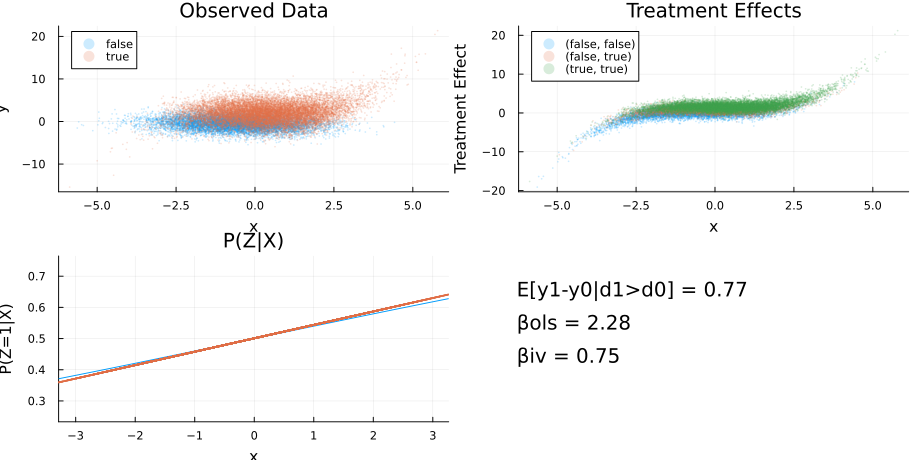

```julia
ezx = x->cdf(Normal(),x)
y,x,z,d,Δ,d0,d1 = sim(25_000, Δ=x->1, ezx=ezx)
plotTE(y,d,x,z,Δ,d0,d1, ezx=ezx)
```

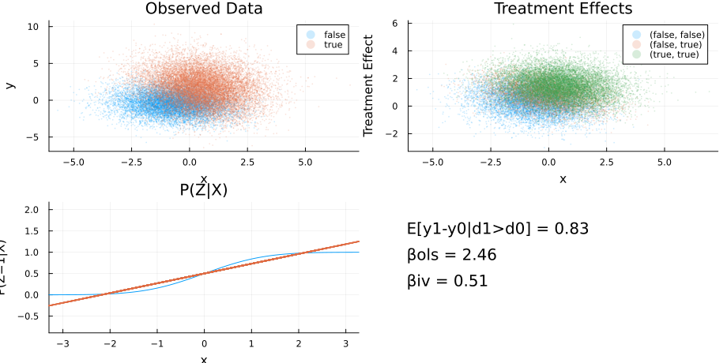

## Simulation: High Bias

```julia
ezx = x->cdf(Normal(),x)
y,x,z,d,Δ,d0,d1 = sim(25_000, Δ=x->(1+x^3/10), ezx=ezx)
plotTE(y,d,x,z,Δ,d0,d1, ezx=ezx)
```

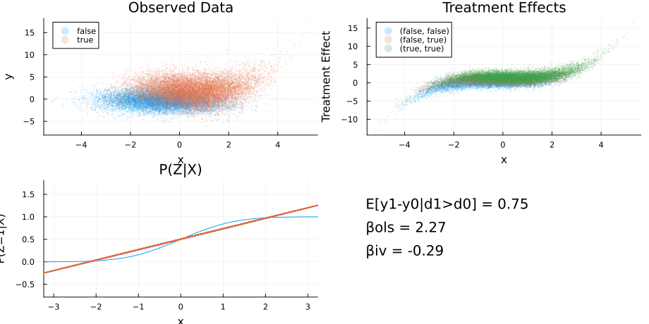

## Observations

- Nonlinearity in $\Er[Z|X]$ and $\Er[Y|X]$ can lead to substantial bias in 2SLS

## What to do?

- Flexibly control for $X$
- If discrete, saturated regression
- Otherwise, doubly robust estimator for average conditional LATE
  - Chernozhukov et al. (2024) chapter 13, `doubleml` python & R package

## Further Reading

- Mogstad and Torgovitsky (2024)

# References

Andrews, Isaiah, James H. Stock, and Liyang Sun. 2019. “Weak Instruments in Instrumental Variables Regression: Theory and Practice.” *Annual Review of Economics* 11 (1): 727–53. https://doi.org/10.1146/annurev-economics-080218-025643.

Blandhol, Christine, John Bonney, Magne Mogstad, and Alexander Torgovitsky. 2025. *When Is TSLS Actually Late?* https://a-torgovitsky.github.io/tslslate.pdf.

Chernozhukov, V., C. Hansen, N. Kallus, M. Spindler, and V. Syrgkanis. 2024. *Applied Causal Inference Powered by ML and AI*. https://causalml-book.org/.

Guggenberger, Patrik, Frank Kleibergen, and Sophocles Mavroeidis. 2024. “A POWERFUL SUBVECTOR ANDERSON–RUBIN TEST IN LINEAR INSTRUMENTAL VARIABLES REGRESSION WITH CONDITIONAL HETEROSKEDASTICITY.” *Econometric Theory* 40 (5): 957–1002. https://doi.org/10.1017/S0266466622000627.

Keane, Michael, and Timothy Neal. 2023. “Instrument Strength in IV Estimation and Inference: A Guide to Theory and Practice.” *Journal of Econometrics* 235 (2): 1625–53. https://doi.org/https://doi.org/10.1016/j.jeconom.2022.12.009.

Lee, David S, Justin McCrary, Marcelo J. Moreira, and Jack Porter. 2022. “Valid t-Ratio Inference for IV.” *American Economic Review* 112 (10): 3260–90. https://doi.org/10.1257/aer.20211063.

Lee, David S, Justin McCrary, Marcelo J Moreira, Jack R Porter, and Luther Yap. 2023. *What to Do When You Can’t Use ’1.96’ Confidence Intervals for IV*. Working Paper No. 31893. Working Paper Series. National Bureau of Economic Research. https://doi.org/10.3386/w31893.

Londschien, Malte, and Peter Bühlmann. 2024. *Weak-Instrument-Robust Subvector Inference in Instrumental Variables Regression: A Subvector Lagrange Multiplier Test and Properties of Subvector Anderson-Rubin Confidence Sets*. https://arxiv.org/abs/2407.15256.

Mogstad, Magne, and Alexander Torgovitsky. 2024. *Instrumental Variables with Unobserved Heterogeneity in Treatment Effects*. Working Paper No. 32927. Working Paper Series. National Bureau of Economic Research. https://doi.org/10.3386/w32927.

Song, Kyunchul. 2021. *Introduction to Econometrics*.

Stock, James H, Jonathan H Wright, and Motohiro Yogo. 2002. “A Survey of Weak Instruments and Weak Identification in Generalized Method of Moments.” *Journal of Business & Economic Statistics* 20 (4): 518–29. https://doi.org/10.1198/073500102288618658.

Stock, James H, and Motohiro Yogo. 2002. *Testing for Weak Instruments in Linear IV Regression*. Working Paper No. 284. Technical Working Paper Series. National Bureau of Economic Research. https://doi.org/10.3386/t0284.

Tuvaandorj, Purevdorj. 2024. “Robust Permutation Tests in Linear Instrumental Variables Regression.” *Journal of the American Statistical Association* 0 (ja): 1–24. https://doi.org/10.1080/01621459.2024.2412363.